# 36-315 Lecture 10, Spring 2016

Sam Ventura

February 15th, 2015

# Interpretting Histograms and Boxplots

# Histograms

Histograms divide the range of the variable we’re interested in into bins, then count how many observations fall into those bins.

By changing the width of the bins or the number of bins, we are changing the resulting histogram.

Histograms are useful for visualizing the marginal distribution of a single variable. As we will see later, they are also useful for visualizing the conditional distributions of one variable given another.

Let’s work with the Cars93 data again.

```r
library(MASS)
library(ggplot2)
library(gridExtra)
data(Cars93)
head(Cars93)
```

```
##   Manufacturer   Model    Type Min.Price Price Max.Price MPG.city
## 1        Acura Integra   Small      12.9  15.9      18.8       25
## 2        Acura  Legend Midsize      29.2  33.9      38.7       18
## 3         Audi      90 Compact      25.9  29.1      32.3       20
## 4         Audi     100 Midsize      30.8  37.7      44.6       19
## 5          BMW    535i Midsize      23.7  30.0      36.2       22
## 6        Buick Century Midsize      14.2  15.7      17.3       22
##   MPG.highway            AirBags DriveTrain Cylinders EngineSize
## 1          31               None      Front         4        1.8
## 2          25 Driver & Passenger      Front         6        3.2
## 3          26        Driver only      Front         6        2.8
## 4          26 Driver & Passenger      Front         6        2.8
## 5          30        Driver only       Rear         4        3.5
## 6          31        Driver only      Front         4        2.2
##   Horsepower  RPM Rev.per.mile Man.trans.avail Fuel.tank.capacity
```

[output cut: 20 more lines]

We’ll start by specifying the number of bins in our histogram.

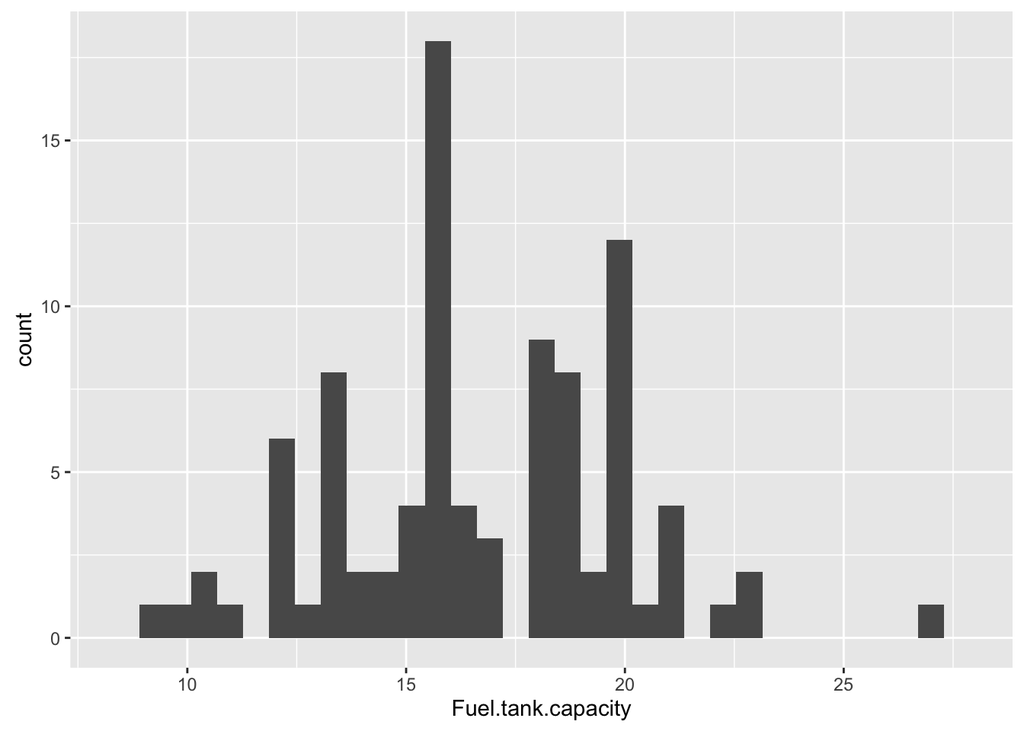

```r
base_plot <- ggplot(Cars93)
base_plot + geom_histogram(bins = 30) + aes(x = Fuel.tank.capacity)
```

Try changing the number of bins to 5, 10, 15, 30, etc. What happens?

Note: It’s best to always say **potential** outlier. Outliers don’t have a universally agreed upon definition in statistics. Outliers are problem/data-dependent.

Be careful about removing outliers. Often, they are informative! We don’t want to remove extreme values if the extreme values are the ones that are the most interesting.

Your data and your graphs tell a story – outliers are a part of this story, so treat them appropriately.

# Histograms – Changing the width of the bins

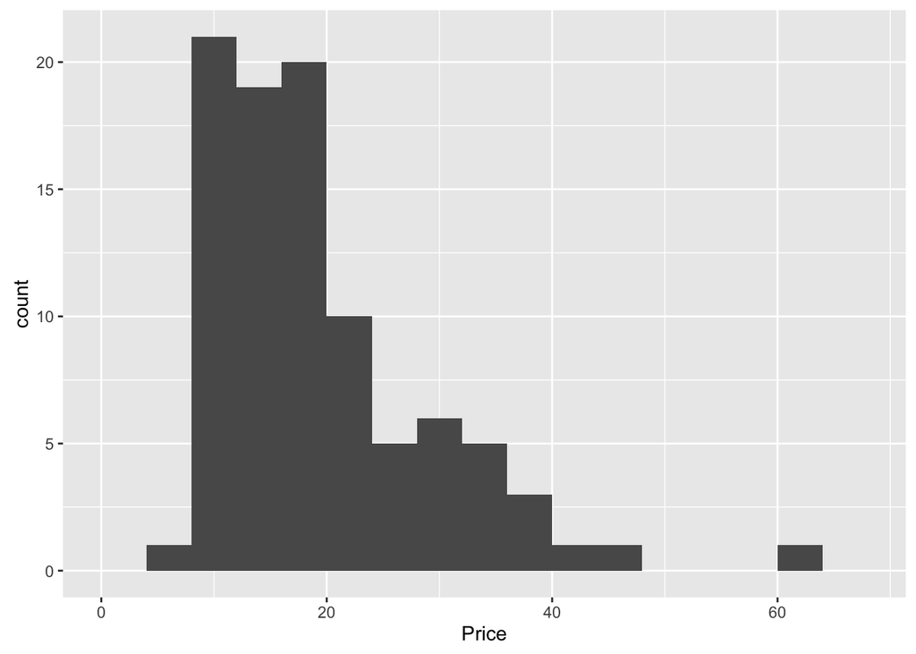

```r
base_plot <- ggplot(Cars93)
base_plot + geom_histogram(binwidth = 4) + aes(x = Price)
```

Try specifying different values of the width of the bins.

- What happens if we choose a `binwidth` of 1?
- With a binwidth of 2, we start to see a smoother distribution.
- With a binwidth of 4, we start to see that the distribution of the car price is skewed right. There is one large mode in the distribution between $10K and $20K, and the distribution of price tails off as the price increases. It is rare to see a price below about $8K – it appears that only one car has a price that low in our dataset. It is also rare to see a price above $40K – it appears that only three cars have prices that high. There is one car with a substantially larger price than the others, costing $60k.

Sometimes, it’s nice to find out more information about the extreme-valued cars.

```r
Cars93[which(Cars93$Price > 40 | Cars93$Price < 8), ]
```

```
##     Manufacturer   Model    Type Min.Price Price Max.Price MPG.city
## 11      Cadillac Seville Midsize      37.5  40.1      42.7       16
## 31          Ford Festiva   Small       6.9   7.4       7.9       31
## 48      Infiniti     Q45 Midsize      45.4  47.9      50.4       17
## 59 Mercedes-Benz    300E Midsize      43.8  61.9      80.0       19
##    MPG.highway            AirBags DriveTrain Cylinders EngineSize
## 11          25 Driver & Passenger      Front         8        4.6
## 31          33               None      Front         4        1.3
## 48          22        Driver only       Rear         8        4.5
## 59          25 Driver & Passenger       Rear         6        3.2
##    Horsepower  RPM Rev.per.mile Man.trans.avail Fuel.tank.capacity
## 11        295 6000         1985              No               20.0
## 31         63 5000         3150             Yes               10.0
## 48        278 6000         1955              No               22.5
## 59        217 5500         2220              No               18.5
##    Passengers Length Wheelbase Width Turn.circle Rear.seat.room
## 11          5    204       111    74          44             31
## 31          4    141        90    63          33             26
## 48          5    200       113    72          42             29
## 59          5    187       110    69          37             27
##    Luggage.room Weight  Origin               Make
## 11           14   3935     USA   Cadillac Seville
## 31           12   1845     USA       Ford Festiva
## 48           15   4000 non-USA       Infiniti Q45
## 59           15   3525 non-USA Mercedes-Benz 300E
```

The Ford Festiva is the cheapest car. It has a very small engine, is very light, has very low horsepower, and gets great gas mileage! It does not have airbags though. Please wear your seatbelt.

The Mercedes-Benz 300E is the most expensive car, at $61.9K. The other expensive cars are the Cadillac Seville and the Infiniti Q45.

# Conditional Distributions with Histograms

Let’s look at some conditional distributions with histograms. We can do this with `facet_wrap` and `facet_grid`.

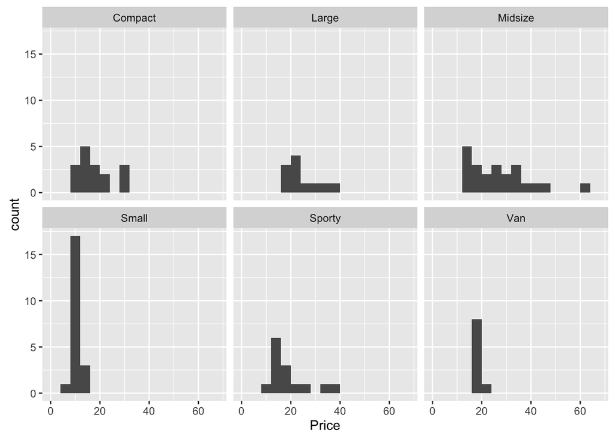

```r
base_plot + geom_histogram(binwidth = 4) + aes(x = Price) + facet_wrap(~Type)
```

Each one of the mini-graphs shows the conditional distribution of car price given each particular car type.

Small cars are hte least expensive. Compact cars are also fairly inexpensive. Vans have a very tight distribution, with almost all vans priced right around $20K. Midsize cars have the most variance in their price distribution, ranging from about $12K to $60K.

Is it easier to compare these conditional distributions when the graphs are side-by-side or when they are stacked?

Side-by-side:

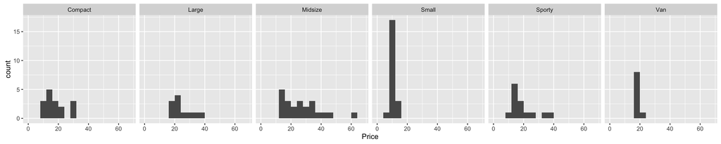

```r
base_plot + geom_histogram(binwidth = 4) + aes(x = Price) + facet_grid(.~Type)
```

Stacked:

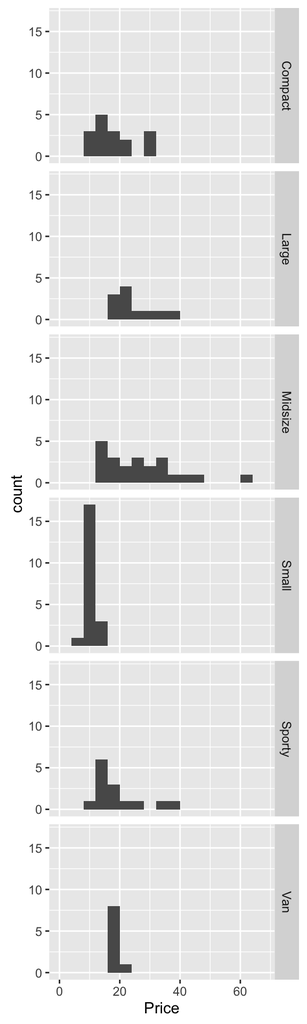

```r
base_plot + geom_histogram(binwidth = 4) + aes(x = Price) + facet_grid(Type~.)
```

# Histograms vs. Boxplots

Let’s compare histograms and boxplots. Which gives you more information?

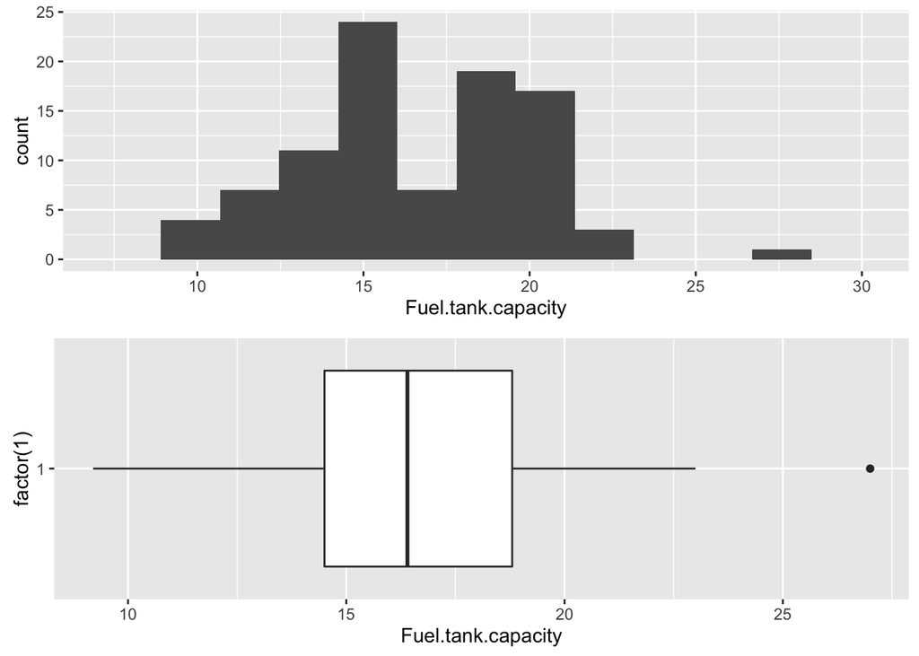

```r
my_hist <- base_plot + geom_histogram(bins = 10) + aes(x = Fuel.tank.capacity)
my_box <- base_plot + geom_boxplot() + aes(y = Fuel.tank.capacity, x = factor(1)) + coord_flip()
grid.arrange(my_hist, my_box)
```

With histograms, you can change some parameters (bin-width, number of bins, colors) to get more information.

With boxplots, you just get what you get.

Boxplots aren’t bad at giving a quick visual summary of the conditional distirbutions, though:

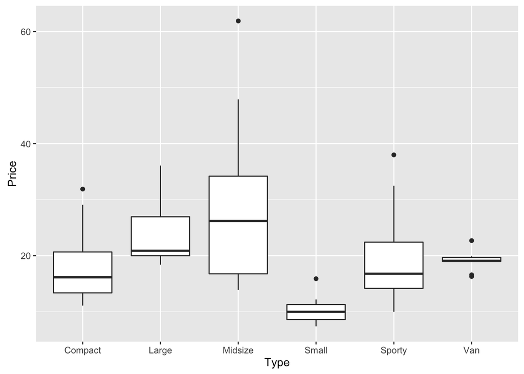

```r
base_plot + geom_boxplot() + aes(x = Type, y = Price)
```

In this graph, you get a very quick measure of the centers and spreads of eacah of the conditional distributions.

On the next lab: How would you sort these boxes by their medians?

You can flip the x and y axes if you prefer:

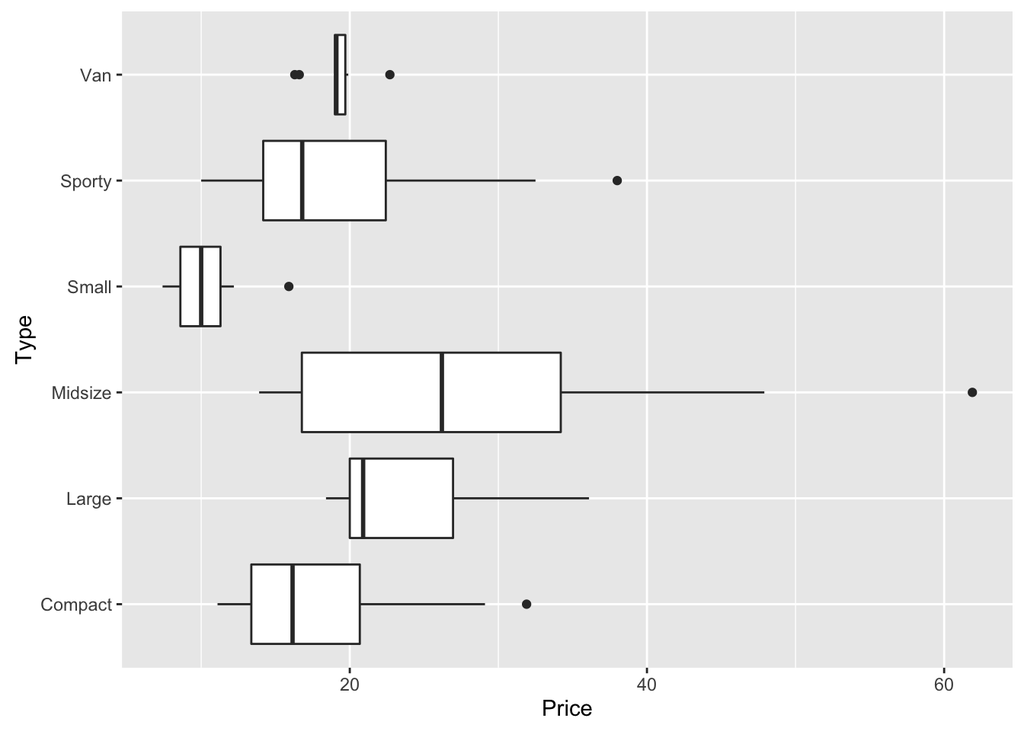

```r
base_plot + geom_boxplot() + aes(x = Type, y = Price) + coord_flip()
```